# WILD 562 Lab4 : Categorical Covariates

Mark Hebblewhite

February 22, 2017

#### Lab4: Categorical Resource Selection

##### General introduction to the biological rationale of this lab was given in the Lab 2 and 3 lab introductions. In Lab 4, we extend the analysis of habitat use by wolves in two wolf packs from 2001-2005 in Banff National Park to multivariate analysis of categorical habitat selection using multiple logistic regressions to estimate a resource selection function (RSF) as a function of the availability of resources.

##### The learning objectives of today’s lab are 1) Data management and processing - a) Process spatial landcover data and make it ready for extraction to a dataframe building on labs 1, 2 and 3. Processing distance to high human use as well. b) Adding XY coordinates to our wolf data frame by running code from source, and then re-building a new dataframe with the new landcover and distance to high human use data attached to the wolfkde dataframe. 2) Review how to summarize coefficients from large numbers of models. 3) Conduct selection ratio’ analysis using the proportional use and availabilities of our wolfkde dataset. 4) Conduct categorical resource selection using logistic regression. 5) Gain an appreciation for the influence of changing the reference category on the model.

##### Note I have supressed the printing of the package loading part of the lab to save space.

##### 1.0 Preliminaries: Data Management

###### Learning about spatial data analysis in R this website is great: http://rspatial.org/spatial/index.html

###### 1.1 Importing Landcover map from an ArcGIS GRID folder with structure Landcover/

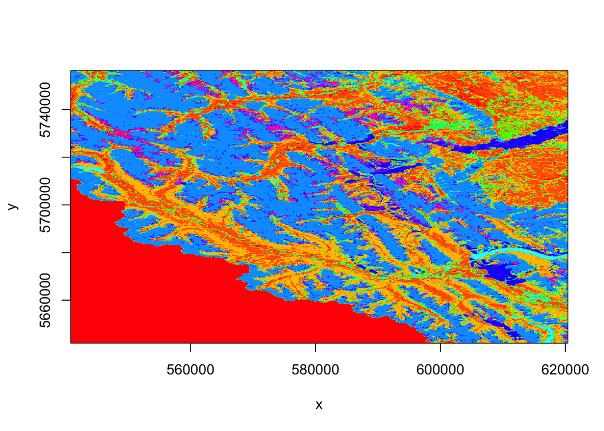

```r
setwd("/Users/mark.hebblewhite/Dropbox/WILD 562/Spring2017/lab4/landcover/")
landcover<-raster("landcover")
image(landcover, col=rainbow(16))
```

```r
#str(landcover)
landcover@data@attributes
```

```
## [[1]]
##    ID   COUNT      HABITATTYPE
## 1   0 1900291
## 2   1  463198     Open Conifer
## 3   2 1862186 Moderate Conifer
## 4   3 1145298   Closed Conifer
## 5  13   37597   Burn-Grassland
## 6  14   12652       Burn-Shrub
## 7  15  309468      Alpine Herb
## 8   9   64429            Water
## 9   4    2695        Deciduous
## 10  5   89214     Mixed forest
## 11  6   48053     Regeneration
## 12  7  189881       Herbaceous
## 13  8  341073            Shrub
## 14 10 3254214         Rock-Ice
## 15 11   10613            Cloud
## 16 12  227876      Burn-Forest
## 17 16  148034     Alpine Shrub
```

##### Note that this ‘legend’ is what we want to keep track of as we transform the data to a GTiff below.

```r
landcover@crs@projargs
```

```
## [1] "+proj=utm +zone=11 +ellps=GRS80 +towgs84=0,0,0,0,0,0,0 +units=m +no_defs"
```

```r
extent(landcover)
```

```
## class       : Extent
## xmin        : 540827.8
## xmax        : 620387.8
## ymin        : 5642002
## ymax        : 5756332
```

```r
landcover
```

```
## class       : RasterLayer
## dimensions  : 3811, 2652, 10106772  (nrow, ncol, ncell)
## resolution  : 30, 30  (x, y)
## extent      : 540827.8, 620387.8, 5642002, 5756332  (xmin, xmax, ymin, ymax)
## coord. ref. : +proj=utm +zone=11 +ellps=GRS80 +towgs84=0,0,0,0,0,0,0 +units=m +no_defs
## data source : /Users/mark.hebblewhite/Dropbox/WILD 562/Spring2017/lab4/landcover/landcover
## names       : landcover
## values      : 0, 16  (min, max)
## attributes  :
##        ID   COUNT  HABITATTYPE
##  from:  0 1900291
##  to  : 16  148034 Alpine Shrub
```

```r
#### now lets write this as a TIFF format (easier to use) to be the same as all other raster stack objects
#### note you can sometime get errors creating a raster stack out of different kinds of rasters
setwd("/Users/mark.hebblewhite/Dropbox/WILD 562/Spring2017/lab4/new/")
writeRaster(landcover, "landcover16.tif", "GTiff", overwrite = TRUE)
landcover16 <- raster("landcover16.tif") # bringing it back in
str(landcover16@data@attributes)
```

```
## List of 1
##  $ :'data.frame':    17 obs. of  2 variables:
##   ..$ ID      : num [1:17] 0 1 2 3 4 5 6 7 8 9 ...
##   ..$ category: Factor w/ 17 levels "10613","1145298",..: 7 14 5 2 9 17 15 6 12 16 ...
```

##### But now note that we have semmingly lost the HABITATTYPE field which did not get transformed through writeRaster

##### Therefore we should go back to the original landcover model, and remap the same Habitat Type field

```r
data1 <- data.frame(landcover@data@attributes[[1]][2:3])
names(landcover16@data@attributes[[1]])[2]<-"COUNT"
landcover16@data@attributes <- merge(landcover16@data@attributes, data1, by="COUNT")
landcover16@data@attributes<-landcover16@data@attributes[c(2,1,3)]
landcover16@data@attributes
```

```
##    ID   COUNT      HABITATTYPE
## 1  11   10613            Cloud
## 2   3 1145298   Closed Conifer
## 3  14   12652       Burn-Shrub
## 4  16  148034     Alpine Shrub
## 5   2 1862186 Moderate Conifer
## 6   7  189881       Herbaceous
## 7   0 1900291
## 8  12  227876      Burn-Forest
## 9   4    2695        Deciduous
## 10 15  309468      Alpine Herb
## 11 10 3254214         Rock-Ice
## 12  8  341073            Shrub
## 13 13   37597   Burn-Grassland
## 14  1  463198     Open Conifer
## 15  6   48053     Regeneration
## 16  9   64429            Water
## 17  5   89214     Mixed forest
```

##### Now lets explore some graphing options

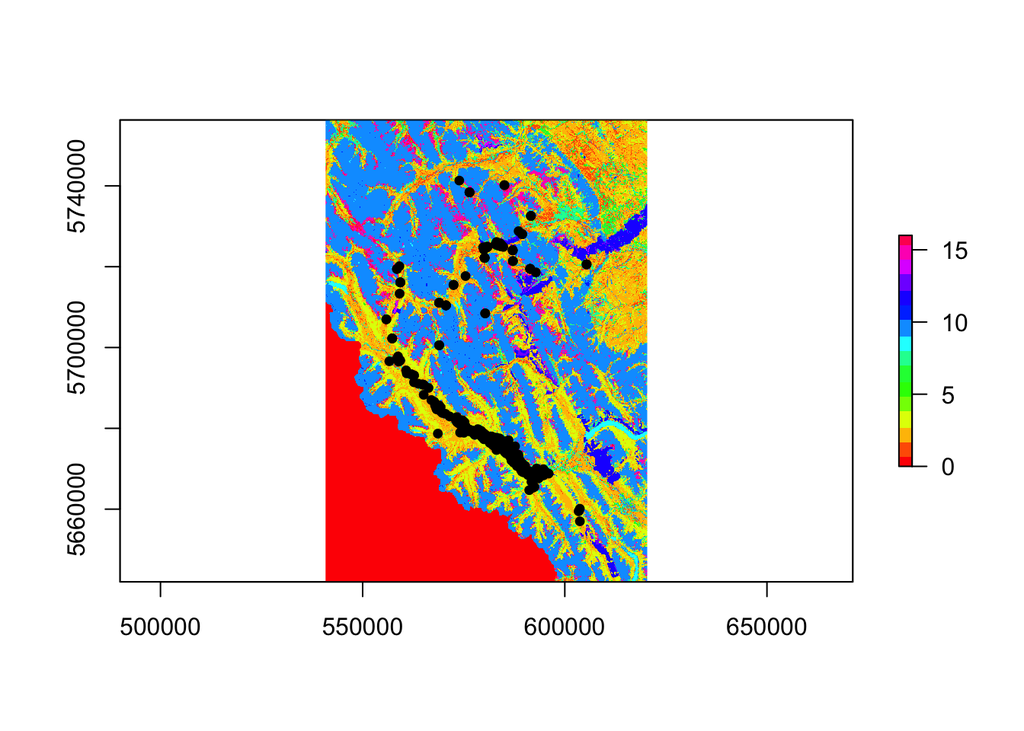

```r
wolfyht<-shapefile("wolfyht.shp")
plot(landcover16, col=rainbow(16))
plot(wolfyht, add=TRUE, type="p", color = "gray25", pch=19, cex = 0.75)
```

```r
extent(landcover16) ### we will see below that this extent is different than below.
```

```
## class       : Extent
## xmin        : 540827.8
## xmax        : 620387.8
## ymin        : 5642002
## ymax        : 5756332
```

##### Lets make a second plot zooming into a specific area of the Red Deer pack

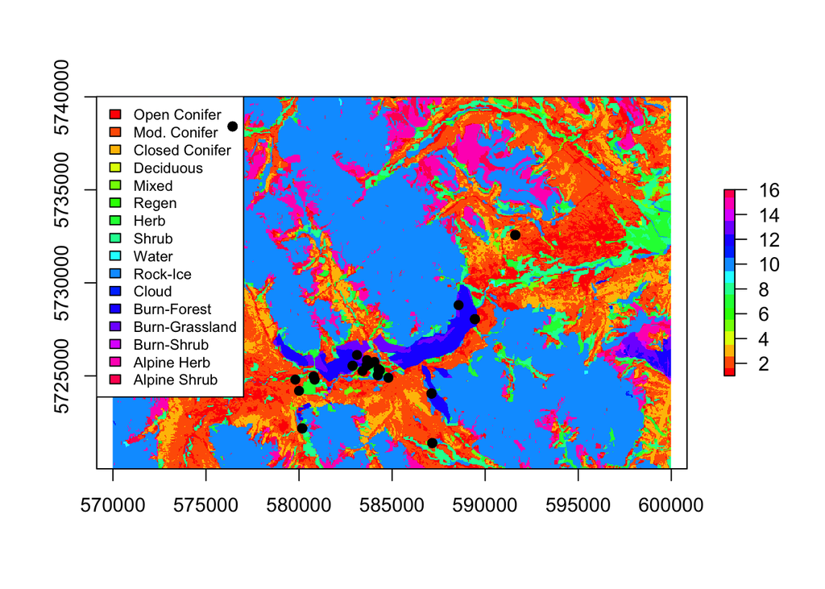

```r
## lets make a second plot zooming into a specific area of the Red Deer pack
yht.raster <- raster()
extent(yht.raster) <- c(xmin=570000, xmax=600000, ymin=5720000, ymax=5740000)
plot(landcover16, col=rainbow(16), ext=yht.raster)
legend("topleft", legend = c("Open Conifer", "Mod. Conifer", "Closed Conifer", "Deciduous", "Mixed", "Regen", "Herb", "Shrub", "Water", "Rock-Ice", "Cloud", "Burn-Forest", "Burn-Grassland", "Burn-Shrub", "Alpine Herb", "Alpine Shrub"), fill = rainbow(16), cex=0.75)
plot(wolfyht, add=TRUE, type="p", color = "gray25", pch=19)
```

##### And next, make a zoomed in model of the elk prey layer

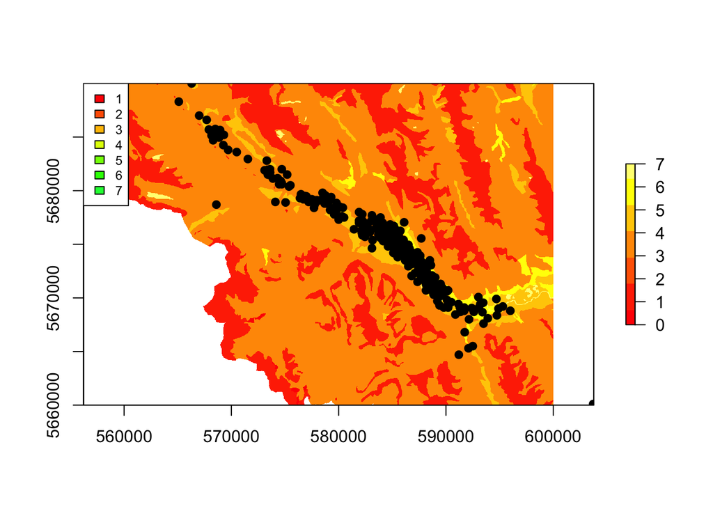

```r
bv.raster <- raster()
extent(bv.raster) <- c(xmin=560000, xmax=600000, ymin=5660000, ymax=5690000)
elk_w<-raster("/Users/mark.hebblewhite/Dropbox/WILD 562/Spring2017/Lab1_rintro/new/lab1_data/elk_w2.tif")
plot(elk_w, col=heat.colors(7), ext=bv.raster)
legend("topleft", legend = c("1", "2", "3", "4", "5", "6", "7"), fill = rainbow(16), cex=0.75)
plot(wolfyht, add=TRUE, type="p", color = "gray25", pch=19)
```

##### Now review the different extents between the elk_w and landcover16 models

```r
extent(elk_w)
```

```
## class       : Extent
## xmin        : 443680.6
## xmax        : 650440.6
## ymin        : 5618416
## ymax        : 5789236
```

```r
#res(elk_w) ## this was also used to check the resolutions were the same, which they were
extent(landcover16)
```

```
## class       : Extent
## xmin        : 540827.8
## xmax        : 620387.8
## ymin        : 5642002
## ymax        : 5756332
```

```r
#res(landcover16)
```

##### Recall that we then have to reset the extent to be the same before we can create a Raster Stack for extracting this landcover covariate again

```r
mask.raster <- raster()
extent(mask.raster) <- c(xmin=443680.6, xmax=650430.4, ymin=5618405, ymax=5789236)
res(mask.raster) = 30
#match projection to elc_habitat shapefile
projection(mask.raster)<- "+proj=utm +zone=11 +datum=NAD83 +units=m +no_defs +ellps=GRS80 +towgs84=0,0,0"
#set all values of mask.raster to zero
mask.raster[]<-0
```

##### First we need to resample the landcover16 model using the nerest neighbor method to have the same raster extent as our ‘mask’. This will take several minutes of system time.

```r
landcover2<-resample(landcover16, mask.raster, method="ngb")
## note here we are resampling to nearest neighbor to preseve the integer value - if you do this using the bilinear resampling you get double format numbers (i.e., not integer values)
extent(landcover2)
```

```
## class       : Extent
## xmin        : 443680.6
## xmax        : 650440.6
## ymin        : 5618416
## ymax        : 5789236
```

#### 1.2 Bringing in the Distance to High Human Access layer - see Lab 2 section 1b.

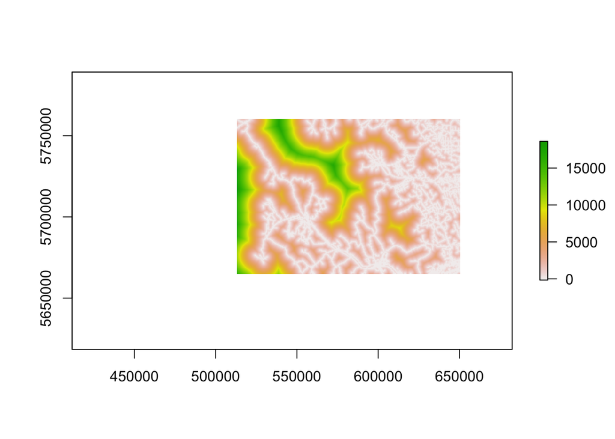

```r
setwd("/Users/mark.hebblewhite/Dropbox/WILD 562/Spring2017/lab4/new/")
disthhu<-raster("DistFromHighHumanAccess2.tif")
plot(disthhu)
```

```r
extent(disthhu)
```

```
## class       : Extent
## xmin        : 443680.6
## xmax        : 650430.4
## ymin        : 5618405
## ymax        : 5789236
```

```r
## note we also need to resample this to exactly match our extent
disthhu2<-resample(disthhu, mask.raster, method="bilinear")
extent(disthhu2)
```

```
## class       : Extent
## xmin        : 443680.6
## xmax        : 650440.6
## ymin        : 5618416
## ymax        : 5789236
```

#### 1.3. Re-extracting both spatial data frame

##### Lets bring in all the data from our original lab 1 data - where ever you still have these data

```r
setwd("/Users/mark.hebblewhite/Dropbox/WILD 562/Spring2017/lab1_rintro/new/Lab1_data")
deer_w<-raster("deer_w2.tif")
moose_w<-raster("moose_w2.tif")
elk_w<-raster("elk_w2.tif") # already brought in above
sheep_w<-raster("sheep_w2.tif")
goat_w<-raster("goat_w2.tif")
wolf_w<-raster("wolf_w2.tif")
elevation2<-raster("Elevation2.tif") #resampled
disthumanaccess2<-raster("DistFromHumanAccess2.tif") #resampled
```

##### stack raster layers (i.e., create raster stack for sampling; must have same extent and resolution)

```r
#all_rasters<-stack(deer_w, moose_w, elk_w, sheep_w, goat_w, wolf_w, elevation2, disthumanaccess2, landcover16)
#Error in compareRaster(x) : different extent
```

#### Note the problem of different extents in using our landcover16 model BEFORE we reprojected it. In the hashed out text above I show the error you get if you used different extents in the raster list.

```r
all_rasters<-stack(deer_w, moose_w, elk_w, sheep_w, goat_w, wolf_w,elevation2, disthumanaccess2, disthhu2, landcover2)
```

##### Next we are going to re-extract covariate values for the wolf used and available datasets based on the Kernel density estimatoe from Lab 2. Recall that for example first we use the rd.data and rd.avail datasets which were a spatialDataPointsFrame needed from Lab 2.

##### Instead of going all the way back to lab 2 and redoing everything again, we are going to use SOURCE as a command to re-run a trimmed down set of commands from Lab 2 to re-extract the rd.data, rd.avail, bv.data, and bv.avail data. Note also that I ‘fixed’ the random generation in the spsample by using the set.seed(11) command which ensures we all should get the same results. Furthermore, we really could do rd.data and bv.data with the steps below, but it is the AVAILABILITY datasets we need to restimate.

##### ?source to find out more about sourcing from script

##### Note we are going to have to make sure our working directory in the Lab2NeededforLab5.R file is correctly pointed to where we have the wolfyht.shp file (in Lab 4/new)

```r
source("/Users/mark.hebblewhite/Dropbox/WILD 562/Spring2017/lab4/new/Lab2NeededforLab5.R", verbose = FALSE)
```

##### Now look at your R objects and see that indeed, you now have rd.data, bv.data, etc. re-estimated from lab 2 to re-extract. Cool!

```r
rd.data<-wolfyht[wolfyht@data$Pack=="Red Deer",]
cov.outRD<-extract(all_rasters, rd.data)

#Extract covariate values for available points
cov.availRD<-extract(all_rasters, rd.avail)

#Extract covariate values for Bow valley wolf data
bv.data<-wolfyht[wolfyht@data$Pack=="Bow valley",]
cov.outBV<-extract(all_rasters, bv.data)

#Extract covariate values for available points
cov.availBV<-extract(all_rasters, bv.avail)
```

#### 1.3 Attaching spatial X, Y data to Used and Available data (visualization, etc)

##### It is sometimes useful to have X, Y locations associated with the different spatial datasets attach coordinates for red deer pack used points . Here we go back to Lab 2 Objective 4 and after we have creted the cov.outRD spatialPointsDataFrame object, we create a new object with X, Y

##### Note here I supressed display of all these steps as they just repeat lab2.

```r
## and Merge the wolf used and avail samples together for the KDE availability estimator
wolfkde <- rbind(wolfused, wolfavail)
#str(wolfkde)
table(wolfkde$used, wolfkde$pack)
```

```
##
##     Bow Valley Red Deer
##   0       1000     1000
##   1        320       93
```

```r
wolfkde$usedFactor <- factor(wolfkde$used, labels=c('0','1'))
write.table(wolfkde, file = "/Users/mark.hebblewhite/Dropbox/WILD 562/Spring2017/lab4/new/wolfkde.csv", row.names=FALSE, na="", col.names=TRUE, sep=",")
wolfkde <- read.csv("/Users/mark.hebblewhite/Dropbox/WILD 562/Spring2017/lab4/new/wolfkde.csv", sep=",")
```

##### Now we can make a single nice plot of the X and Y locations by Used by Pack

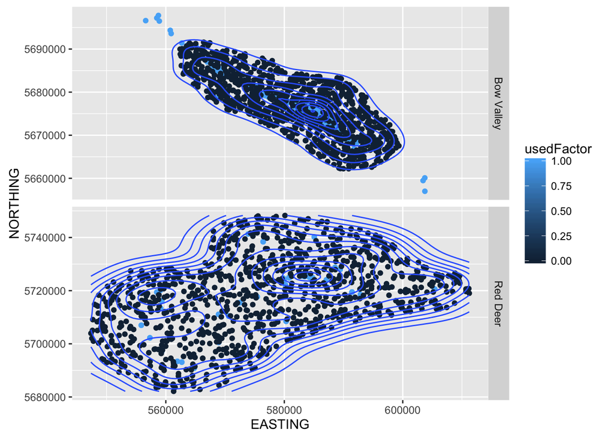

```r
ggplot(wolfkde, aes(x=EASTING, y = NORTHING, color=usedFactor)) + geom_point() + stat_density2d() + facet_grid(pack ~ ., scales="free")
```

#### Objective 2.0 Univariate Model-fitting commands from lab 3 - extracting covariate tables from multiple models

##### note in the script I also did this for Bv and rd wolf packs

```r
### First for all packs
elev <- glm(used ~ Elevation2, family=binomial(logit), data=wolfkde)
distacc <- glm(used ~ DistFromHumanAccess2, family=binomial(logit), data=wolfkde)
disthha <- glm(used ~ DistFromHighHumanAccess2, family=binomial(logit), data=wolfkde)
sheep <- glm(used ~ sheep_w2, family=binomial(logit), data=wolfkde)
goat <- glm(used ~ goat_w2, family=binomial(logit), data=wolfkde)
elk <- glm(used ~ elk_w2, family=binomial(logit), data=wolfkde)
moose <- glm(used ~ moose_w2, family=binomial(logit), data=wolfkde)
deer <- glm(used ~ deer_w2, family=binomial(logit), data=wolfkde)

# creating tables of B, SE
# First grab all of the estimates and standard errors
models = rbind(summary(elev)$coefficients[,1:2], summary(disthha)$coefficients[,1:2], summary(distacc)$coefficients[,1:2], summary(sheep)$coefficients[,1:2], summary(goat)$coefficients[,1:2], summary(elk)$coefficients[,1:2], summary(moose)$coefficients[,1:2], summary(deer)$coefficients[,1:2])
# Name your models
modelnames = c("elev","disthha", "distacc", "sheep", "goat", "elk", "moose", "deer")
# Now put all of your estimates in a pretty table with names that you'll remember!
estimates.all = matrix(models, nrow=2*length(modelnames), ncol=2, dimnames = list(paste(rep(modelnames, each=2),c("intercept", "coefficient")), c("B", "SE")))
estimates.all
```

```
##                                 B           SE
## elev intercept       7.8700233711 4.890318e-01
## elev coefficient    -0.0054584608 3.040050e-04
## disthha intercept   -1.1474085422 6.657412e-02
## disthha coefficient -0.0002291432 2.827032e-05
## distacc intercept   -0.3818602605 8.177586e-02
## distacc coefficient -0.0021183738 1.624785e-04
## sheep intercept     -1.1351469715 1.057360e-01
## sheep coefficient   -0.1294221421 3.505414e-02
## goat intercept      -0.1165489918 1.022388e-01
## goat coefficient    -0.5813312875 4.366483e-02
## elk intercept       -5.8849656775 3.027504e-01
## elk coefficient      1.1223979754 6.989865e-02
## moose intercept     -3.1326064022 1.889996e-01
## moose coefficient    0.4417215520 4.501132e-02
## deer intercept      -5.9335173841 3.064989e-01
## deer coefficient     1.1181928210 6.933106e-02
```

#### Objective 3.0 Categorical Resource Selection Functions

##### The first thing we need to do is add a column with the name habitat type (landcover) in it to help us keep track of what the different landcover codes mean.

```r
levels(wolfkde$landcover16) ## see, all we have is landcover code
```

```r
wolfkde$habitatType = ifelse(wolfkde$landcover16 == 0, "NA",
                            ifelse(wolfkde$landcover16 == 1, "Open Conifer",
                            ifelse(wolfkde$landcover16 == 2, "Moderate Conifer",
                            ifelse(wolfkde$landcover16 == 3, "Closed Conifer",
                            ifelse(wolfkde$landcover16 == 4, "Deciduous",
                            ifelse(wolfkde$landcover16 == 5, "Mixed",
                            ifelse(wolfkde$landcover16 == 6, "Regen",
                            ifelse(wolfkde$landcover16 == 7, "Herbaceous",
                            ifelse(wolfkde$landcover16 == 8, "Shrub",
                            ifelse(wolfkde$landcover16 == 9, "Water",
                            ifelse(wolfkde$landcover16 == 10, "Rock-Ice",
                            ifelse(wolfkde$landcover16 == 11, "Cloud",
                            ifelse(wolfkde$landcover16 == 12, "Burn-Forest",
                            ifelse(wolfkde$landcover16 == 13, "Burn-Grassland",
                            ifelse(wolfkde$landcover16 == 14, "Burn-Shrub",
                            ifelse(wolfkde$landcover16 == 15, "Alpine Herb", "Alpine Shrub"))))))))))))))))

table(wolfkde$landcover16, wolfkde$used)
```

```
##
##        0   1
##   0    2   0
##   1   92  37
##   2  557 175
##   3  429  58
##   4    3   0
##   5   17  29
##   6    2   0
##   7   35  21
##   8   87  34
##   9    8  12
##   10 629  10
##   11   2   0
##   12  39  30
##   13   8   5
##   14   1   0
##   15  55   0
##   16  34   2
```

##### Note: that each of you will get slightly different AVAILABILITIES because of your own random sampling of availability. This is particularily problematic for rare landcover types like 4 (decid), 6 (regen), clouds (11), etc. Thus for some of you, your table may look slightly different and you will have to keep track of landcover types yourself.

##### Alternatively, redo the analyses with the set.seed(11) code in the Lab2NeededforLab5.R code that I have now updated.

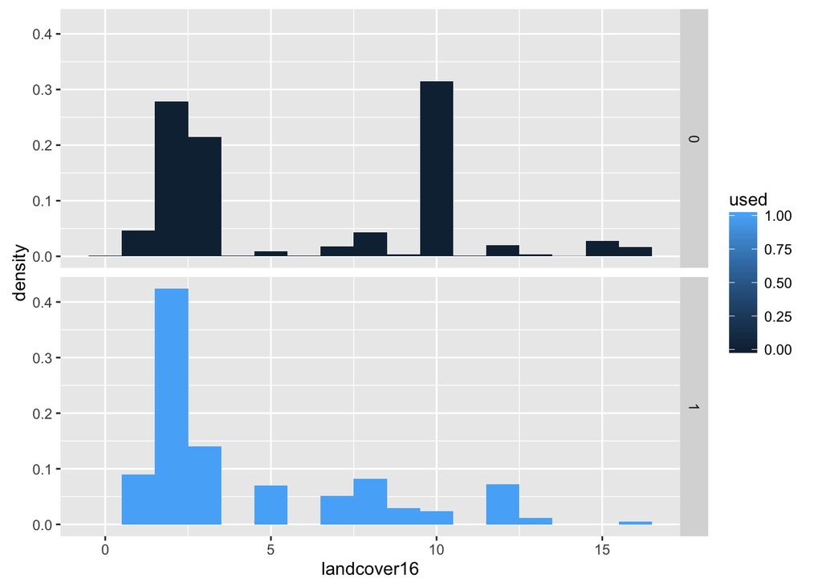

```r
## this graph shows the differences in the proportions between used and available for both packs
ggplot(wolfkde, aes(x=landcover16, y=..density.., fill = used)) +geom_histogram(binwidth = 1) + facet_grid(used~.)
```

##### Note: We will have to discuss what to do with NA’s and Cloud? For now, we will decide to remove clouds as missing data

```r
wolfkde2 <- wolfkde[wolfkde$landcover16 != 11, ]
wolfkde3 <-wolfkde2[wolfkde2$landcover16 != 0, ]
table(wolfkde3$landcover16, wolfkde3$usedFactor)
```

```
##
##        0   1
##   1   92  37
##   2  557 175
##   3  429  58
##   4    3   0
##   5   17  29
##   6    2   0
##   7   35  21
##   8   87  34
##   9    8  12
##   10 629  10
##   12  39  30
##   13   8   5
##   14   1   0
##   15  55   0
##   16  34   2
```

```r
## see we have removed clouds and NA's
```

##### Next I will create a ‘legend’ file (names.m) to help us keep track of contrasts

```r
names.m = data.frame(unique(wolfkde3$landcover16),unique(wolfkde3$habitatType))
# Now I put it order
names.m = names.m[order(names.m)[1:15],]
names.m
```

```
##    unique.wolfkde3.landcover16. unique.wolfkde3.habitatType.
## 4                             1                 Open Conifer
## 2                             2             Moderate Conifer
## 7                             3               Closed Conifer
## 15                            4                    Deciduous
## 10                            5                        Mixed
## 13                            6                        Regen
## 5                             7                   Herbaceous
## 1                             8                        Shrub
## 11                            9                        Water
## 8                            10                     Rock-Ice
## 9                            12                  Burn-Forest
## 3                            13               Burn-Grassland
## 14                           14                   Burn-Shrub
## 12                           15                  Alpine Herb
## 6                            16                 Alpine Shrub
```

```r
# Define a factor variable, landcov.f, # the sorted table makes defining the names of your factor level easy!

wolfkde3$landcov.f = factor(wolfkde3$landcover16,labels = names.m$unique.wolfkde3.habitatType)

#Note that there are many alternative ways of defining your landcover/habitattype
# as a factor. This method seemed most explicit in terms of defining the design matrix
table(wolfkde3$landcov.f, wolfkde3$usedFactor)
```

```
##
##                      0   1
##   Open Conifer      92  37
##   Moderate Conifer 557 175
##   Closed Conifer   429  58
##   Deciduous          3   0
##   Mixed             17  29
##   Regen              2   0
##   Herbaceous        35  21
##   Shrub             87  34
##   Water              8  12
##   Rock-Ice         629  10
##   Burn-Forest       39  30
##   Burn-Grassland     8   5
##   Burn-Shrub         1   0
##   Alpine Herb       55   0
##   Alpine Shrub      34   2
```

#### Objective 3.1 Univariate Selection Ratio’s

##### First we will estimate MAnly’s selection ratio by comparing the ratio of used and available locations to each other, and taking the natural logaritm of those in R.

```r
landcovSelection <- table(wolfkde3$landcov.f, wolfkde3$usedFactor)
landcovSelection2 <- as.data.frame.matrix(landcovSelection)
colnames(landcovSelection2)[1:2] <- c("avail","used")
landcovSelection2$selection <- landcovSelection2$used / landcovSelection2$avail
landcovSelection2$lnSelection <- log(landcovSelection2$selection)
landcovSelection2
```

```
##                  avail used  selection lnSelection
## Open Conifer        92   37 0.40217391  -0.9108707
## Moderate Conifer   557  175 0.31418312  -1.1577793
## Closed Conifer     429   58 0.13519814  -2.0010139
## Deciduous            3    0 0.00000000        -Inf
## Mixed               17   29 1.70588235   0.5340825
## Regen                2    0 0.00000000        -Inf
## Herbaceous          35   21 0.60000000  -0.5108256
## Shrub               87   34 0.39080460  -0.9395476
## Water                8   12 1.50000000   0.4054651
## Rock-Ice           629   10 0.01589825  -4.1415462
## Burn-Forest         39   30 0.76923077  -0.2623643
## Burn-Grassland       8    5 0.62500000  -0.4700036
## Burn-Shrub           1    0 0.00000000        -Inf
## Alpine Herb         55    0 0.00000000        -Inf
## Alpine Shrub        34    2 0.05882353  -2.8332133
```

[figure not shown]

```r
## lets make a plot of the Manly Selectivity Coefficients
plot(unique(wolfkde3$landcov.f), landcovSelection2$lnSelection, las=3)
```

##### This is a simple histogram of the Manly’s selectivity coefficients as a function of landcover types

```r
## it might be handy to save this
write.table(landcovSelection2, "wolfselection.csv", sep=",", row.names = TRUE, col.names=TRUE)
```

#### Objective 4. Logistic Regression

##### Lastly, we will learn about analyzing categorical variables using a new approach compared to categories. To learn more about how R uses contrasts to set the design matrix in any linear model search for help on contrast matrices

##### Even though this may seem ‘new’ if you have ever done ANOVA (a linear model) in R, you have used contrast matrices to do so.

```r
contrasts(wolfkde3$landcov.f) = contr.treatment(15) ## note here also that in my case I had 15 landcover types
# To see the design matrix assigned
attributes(wolfkde3$landcov.f)
```

```
## $levels
##  [1] "Open Conifer"     "Moderate Conifer" "Closed Conifer"
##  [4] "Deciduous"        "Mixed"            "Regen"
##  [7] "Herbaceous"       "Shrub"            "Water"
## [10] "Rock-Ice"         "Burn-Forest"      "Burn-Grassland"
## [13] "Burn-Shrub"       "Alpine Herb"      "Alpine Shrub"
##
## $class
## [1] "factor"
##
## $contrasts
##                  2 3 4 5 6 7 8 9 10 11 12 13 14 15
## Open Conifer     0 0 0 0 0 0 0 0  0  0  0  0  0  0
## Moderate Conifer 1 0 0 0 0 0 0 0  0  0  0  0  0  0
## Closed Conifer   0 1 0 0 0 0 0 0  0  0  0  0  0  0
## Deciduous        0 0 1 0 0 0 0 0  0  0  0  0  0  0
## Mixed            0 0 0 1 0 0 0 0  0  0  0  0  0  0
## Regen            0 0 0 0 1 0 0 0  0  0  0  0  0  0
## Herbaceous       0 0 0 0 0 1 0 0  0  0  0  0  0  0
## Shrub            0 0 0 0 0 0 1 0  0  0  0  0  0  0
## Water            0 0 0 0 0 0 0 1  0  0  0  0  0  0
## Rock-Ice         0 0 0 0 0 0 0 0  1  0  0  0  0  0
## Burn-Forest      0 0 0 0 0 0 0 0  0  1  0  0  0  0
## Burn-Grassland   0 0 0 0 0 0 0 0  0  0  1  0  0  0
## Burn-Shrub       0 0 0 0 0 0 0 0  0  0  0  1  0  0
## Alpine Herb      0 0 0 0 0 0 0 0  0  0  0  0  1  0
## Alpine Shrub     0 0 0 0 0 0 0 0  0  0  0  0  0  1
```

```r
levels(wolfkde3$landcov.f)
```

```
##  [1] "Open Conifer"     "Moderate Conifer" "Closed Conifer"
##  [4] "Deciduous"        "Mixed"            "Regen"
##  [7] "Herbaceous"       "Shrub"            "Water"
## [10] "Rock-Ice"         "Burn-Forest"      "Burn-Grassland"
## [13] "Burn-Shrub"       "Alpine Herb"      "Alpine Shrub"
```

##### Note that while we have cleaned up the clouds and NA’s, what shoull we do about Burned-Grassland, Burned-Herbaceous and Burn-Forests? Reclassify as Burned? We will return to this in a minute. Here, checking above, we see that 11, 12, and 13 are all burns.

```r
levels(wolfkde3$landcov.f)[11:13] = "Burn"
## note this then reduces us from 15 to 13 categories
contrasts(wolfkde3$landcov.f) = contr.treatment(13)
attributes(wolfkde3$landcov.f)
```

```
## $levels
##  [1] "Open Conifer"     "Moderate Conifer" "Closed Conifer"
##  [4] "Deciduous"        "Mixed"            "Regen"
##  [7] "Herbaceous"       "Shrub"            "Water"
## [10] "Rock-Ice"         "Burn"             "Alpine Herb"
## [13] "Alpine Shrub"
##
## $class
## [1] "factor"
##
## $contrasts
##                  2 3 4 5 6 7 8 9 10 11 12 13
## Open Conifer     0 0 0 0 0 0 0 0  0  0  0  0
## Moderate Conifer 1 0 0 0 0 0 0 0  0  0  0  0
## Closed Conifer   0 1 0 0 0 0 0 0  0  0  0  0
## Deciduous        0 0 1 0 0 0 0 0  0  0  0  0
## Mixed            0 0 0 1 0 0 0 0  0  0  0  0
## Regen            0 0 0 0 1 0 0 0  0  0  0  0
## Herbaceous       0 0 0 0 0 1 0 0  0  0  0  0
## Shrub            0 0 0 0 0 0 1 0  0  0  0  0
## Water            0 0 0 0 0 0 0 1  0  0  0  0
## Rock-Ice         0 0 0 0 0 0 0 0  1  0  0  0
## Burn             0 0 0 0 0 0 0 0  0  1  0  0
## Alpine Herb      0 0 0 0 0 0 0 0  0  0  1  0
## Alpine Shrub     0 0 0 0 0 0 0 0  0  0  0  1
```

```r
# note how the design matrix has collapsed burn into one category? What other categories should we consider?
```

##### First, we will use Logistic regression incorectly analyzing treating landcover16 as a continuous covariate

```r
naive.nf = glm(used~landcover16,data=wolfkde3, family=binomial(logit))
summary(naive.nf)
```

```
##
## Call:
## glm(formula = used ~ landcover16, family = binomial(logit), data = wolfkde3)
##
## Deviance Residuals:
##     Min       1Q   Median       3Q      Max
## -0.7438  -0.7101  -0.5324  -0.4822   2.3622
##
## Coefficients:
##             Estimate Std. Error z value Pr(>|z|)
## (Intercept) -1.03803    0.08729  -11.89  < 2e-16 ***
## landcover16 -0.10554    0.01497   -7.05 1.79e-12 ***
## ---
## Signif. codes:  0 '***' 0.001 '**' 0.01 '*' 0.05 '.' 0.1 ' ' 1
##
## (Dispersion parameter for binomial family taken to be 1)
##
##     Null deviance: 2207.4  on 2408  degrees of freedom
## Residual deviance: 2152.0  on 2407  degrees of freedom
## AIC: 2156
##
## Number of Fisher Scoring iterations: 4
```

##### We have incorrectly treated landcover code (1 to 16) as a continuous covariate!